# An example of RNA-seq differential expression analysis

Dario Righelli

17/04/2018

# 1 The data

We will use the data from [@peixoto2015data]. The gene-level read counts are available on [Github](https://github.com/drisso/peixoto2015_tutorial). To be faster, I already put a copy of this repository in our repository.

Briefly, the dataset consists of 5 biological replicates per three conditions: controls, fear-condition (memory formation), and memory retrieval.

We also have access to a list of negative control genes, i.e., genes that are not influenced by the biological effect of interest, and to a list of positive control genes, i.e., genes known to be differentially expressed with respect to the biological effect of interest.

We will use these data to show how to perform a typical differential expression workflow, using edgeR and DESeq2.

# 2 Packages needed

```r
library(RColorBrewer)
library(EDASeq)
library(DESeq2)
library(RUVSeq)
library(edgeR)
library(NOISeq)
library(kableExtra)
```

# 3 Preliminary fundamental steps

Before starting this analysis the raw data (**FASTQ**) have been already independently mapped to the reference genome (mouse) with the **STAR** software outside R. Producing, in such a way, one BAM file for each sample. The mapping process consists in assigning the sequence reads to specific regions of the genome. The precision of the mapping step depends on the software used and on the parameters used. NB It is a time demanding step.

Then, in order to quantify the features (genes), the BAM files have been processed together with a **GTF** file to assign the mapped reads to specific features. As many reads (for each sample) are assigned to a gene as highly is expressed that gene (in that sample). This process can be performed in R by aid of **featureCounts** function of **RSubread** package. The final result of this process is a matrix with the genes on the rows and the samples on the columns. Each cell c[i,j] of the matrix contains the number of reads assigned to i-th feature in the j-th sample.

Today, we’ll work starting with this matrix (the count matrix).

# 4 Exploratory Data Analysis

After reading the counts and the positive and negative control genes in R, we filter out the non expressed genes.

```r
data_dir <- "./peixoto2015_tutorial/Peixoto_Input_for_Additional_file_1/"
fc <- read.table(paste0(data_dir, "Peixoto_CC_FC_RT.txt"), row.names=1, header=TRUE)

negControls <- read.table(paste0(data_dir, "Peixoto_NegativeControls.txt"), sep='\t', header=TRUE, as.is=TRUE)

positive <- read.table(paste0(data_dir, "Peixoto_positive_controls.txt"), as.is=TRUE, sep='\t', header=TRUE)

x <- as.factor(rep(c("CC", "FC", "RT"), each=5))
names(x) <- colnames(fc)

cat("Number of starting features: ", dim(fc)[1], "\n")
```

```
## Number of starting features:  37310
```

# 5 Filtering

Some of the quantified features (genes) could be very low expressed (presenting values close to 0). This can affect our analysis, in particular in the detection of differentially expressed genes. In order to avoid this bias, we filter out these genes.

The filtering can be made with different approaches:

```r
filter <- apply(fc, 1, function(x) length(x[which(x>10)])>5)
filtered <- as.matrix(fc)[filter,]
cpmfiltered <- NOISeq::filtered.data(fc, factor=x, norm=FALSE, method=1, cv.cutoff=100, cpm=1)
```

```
## Filtering out low count features...
## 15104 features are to be kept for differential expression analysis with filtering method 1
```

```r
wilfiltered <- NOISeq::filtered.data(fc, factor=x, norm=FALSE, method=2, cv.cutoff=100, cpm=1)
```

```
## Filtering out low count features...
## 21795 features are to be kept for differential expression analysis with filtering method 2
```

```r
propfiltered <- NOISeq::filtered.data(fc, factor=x, norm=FALSE, method=3, cv.cutoff=100, cpm=1)
```

```
## Filtering out low count features...
## 14920 features are to be kept for differential expression analysis with filtering method 3
```

```r
cat("Classical approach filtered features: ", (dim(fc)[1]-dim(filtered)[1]), "\n")
```

```
## Classical approach filtered features:  19302
```

```r
cat("CPM approach filtered features: ", (dim(fc)[1]-dim(cpmfiltered)[1]), "\n")
```

```
## CPM approach filtered features:  22206
```

```r
cat("Wilcoxon approach filtered features: ", (dim(fc)[1]-dim(wilfiltered)[1]), "\n")
```

```
## Wilcoxon approach filtered features:  15515
```

```r
cat("Proportion approach filtered features: ", (dim(fc)[1]-dim(propfiltered)[1]), "\n")
```

```
## Proportion approach filtered features:  22390
```

We are not interested in which is the best one here, so we choose the classical one. When you perform a real analysis the best approach is to use the one which is filtering not too much and not too few genes.

Now we store the filtered-in genes also for the negative and positive controls.

```r
negCon <- intersect(negControls[,2], rownames(filtered))
FCup <- intersect(positive[positive[,3]=="UP",1], rownames(filtered))
FCdown <- intersect(positive[positive[,3]=="DOWN",1], rownames(filtered))
RTup <- intersect(positive[positive[,4]=="UP",1], rownames(filtered))
RTdown <- intersect(positive[positive[,4]=="DOWN",1], rownames(filtered))

colors <- brewer.pal(9, "Set1")
colLib <- colors[x]
```

# 6 Normalization

In order to better compare the differences between the conditions, we need to normalize the data. Multiple approaches are available for the normalization. Several packages allow to normalize the data:

- EDASeq package the betweenLaneNormalization function implements:
  - Upper Quartile: a normalization based on the third quartile (75% of distribution)
  - Median: a normalization based on the median of the distribution.
- there are some others implementing the same normalizations or their owns.

There is no best normalization, it all depends on the dataset and on the final results.

By aid of *EDASeq* package, we can also use the *plotRLE* and *plotPCA* functions to explore the normalized data.

## 6.1 Upper quartile

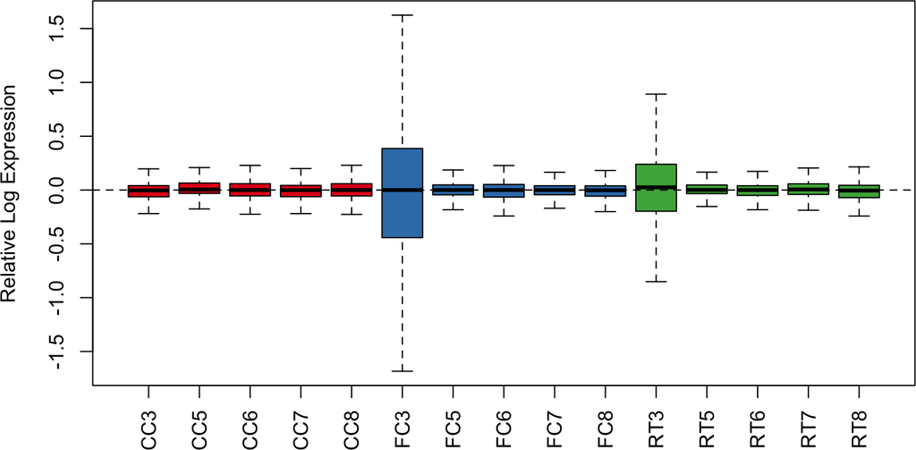

```r
uq <- betweenLaneNormalization(filtered, which="upper")

plotRLE(uq, col=colLib, outline=FALSE, las=3, ylab="Relative Log Expression", cex.axis=1, cex.lab=1)
```

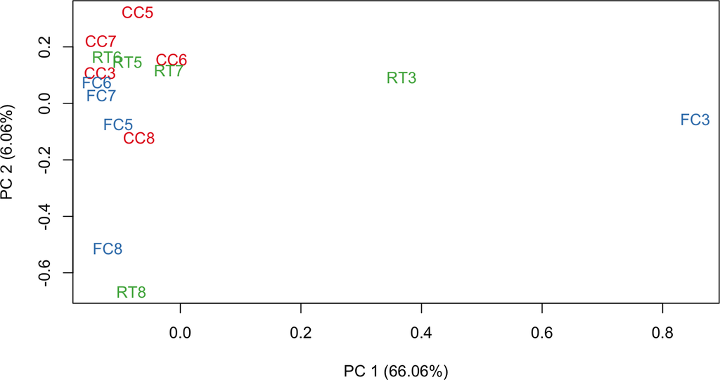

```r
plotPCA(uq, col=colLib, cex=1, cex.axis=1, cex.lab=1)
```

From these plots we notice that the data points denoted with “3” and “8” are somewhat different from the rest of the samples.

For now, let’s filter out these samples.

```r
idx <- grep("[3,8]", colnames(fc), invert = TRUE)
filter <- apply(fc[, idx], 1, function(x) length(x[which(x>10)])>5)
filtered <- as.matrix(fc)[filter, idx]

x <- as.factor(rep(c("CC", "FC", "RT"), each=3))
names(x) <- colnames(filtered)
colLib <- colors[x]
```

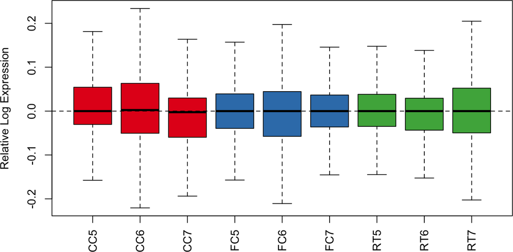

```r
uq <- betweenLaneNormalization(filtered, which="upper")

plotRLE(uq, col=colLib, outline=FALSE, las=3, ylab="Relative Log Expression", cex.axis=1, cex.lab=1)
```

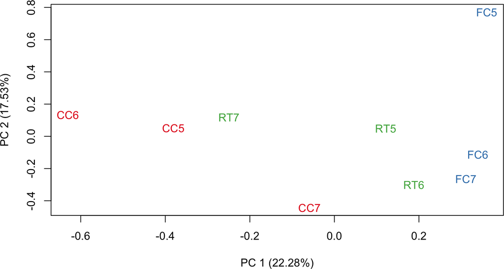

```r
plotPCA(uq, col=colLib, cex=1, cex.axis=1, cex.lab=1)
```

# 7 Differential expression with DESeq2

First, we need to create a `DESeqDataSet` object to store the count matrix and the sample-level information.

```r
dds <- DESeqDataSetFromMatrix(countData = filtered,
                              colData = data.frame(Condition = x,
                                                   Expt = substring(colnames(filtered), 3)),
                              design = ~ Condition)
dds
```

```
## class: DESeqDataSet
## dim: 17513 9
## metadata(1): version
## assays(1): counts
## rownames(17513): ENSMUSG00000000001 ENSMUSG00000000028 ...
##   ENSMUSG00000093351 ENSMUSG00000093364
## rowData names(0):
## colnames(9): CC5 CC6 ... RT6 RT7
## colData names(2): Condition Expt
```

```r
colData(dds)
```

```
## DataFrame with 9 rows and 2 columns
##     Condition     Expt
##      <factor> <factor>
## CC5        CC        5
## CC6        CC        6
## CC7        CC        7
## FC5        FC        5
## FC6        FC        6
## FC7        FC        7
## RT5        RT        5
## RT6        RT        6
## RT7        RT        7
```

To test for the differential expression, we can simply call the wrapper function

```r
dds <- DESeq(dds)
```

This function runs the following in this order.

```r
dds <- estimateSizeFactors(dds)
dds <- estimateDispersions(dds)
dds <- nbinomWaldTest(dds)
```

Let’s explore the results.

```r
res <- results(dds)
res
```

```
## log2 fold change (MLE): Condition RT vs CC
## Wald test p-value: Condition RT vs CC
## DataFrame with 17513 rows and 6 columns
##                            baseMean      log2FoldChange              lfcSE
##                           <numeric>           <numeric>          <numeric>
## ENSMUSG00000000001 1763.50400444911 -0.0177331849973273 0.0669311141798314
## ENSMUSG00000000028 87.5894307443878   0.124859108650337  0.198235825376245
## ENSMUSG00000000037 42.0966758096306  -0.110797543558516  0.286404844786224
## ENSMUSG00000000049 16.7311068941933  -0.382140515386707   0.46849421626665
## ENSMUSG00000000056 2814.87211111275  0.0957786590950601 0.0685021893499775
## ...                             ...                 ...                ...
## ENSMUSG00000093233 14.3611112355321   0.218066948728638  0.505036665005382
## ENSMUSG00000093319  25.812238818714   0.145336414548021  0.357785330235829
## ENSMUSG00000093345 24.7549688131244 -0.0404612723529082  0.365812557887645
## ENSMUSG00000093351 139.648451096219  -0.352834801174409  0.165828518975259
## ENSMUSG00000093364  531.38259549382   0.414087162277891  0.278809350739448
##                                  stat             pvalue              padj
##                             <numeric>          <numeric>         <numeric>
## ENSMUSG00000000001 -0.264946807096048   0.79105043952234  0.99990561413533
## ENSMUSG00000000028  0.629851382379337  0.528791824232542  0.99990561413533
## ENSMUSG00000000037 -0.386856387297555  0.698862529933282  0.99990561413533
## ENSMUSG00000000049  -0.81567819221317   0.41468421496126                NA
## ENSMUSG00000000056   1.39818391213348  0.162057846579949  0.99990561413533
## ...                               ...                ...               ...
## ENSMUSG00000093233  0.431784390795299  0.665898125326204                NA
## ENSMUSG00000093319  0.406211217358254  0.684587412690426  0.99990561413533
## ENSMUSG00000093345 -0.110606570169566  0.911928337216788                NA
## ENSMUSG00000093351  -2.12770881242117 0.0333612338155685 0.830124254686647
## ENSMUSG00000093364   1.48519825888071  0.137491313110878  0.99990561413533
```

```r
resna <- res[!is.na(res$padj),]
resna[resna$padj < 0.05,]
```

```
## log2 fold change (MLE): Condition RT vs CC
## Wald test p-value: Condition RT vs CC
## DataFrame with 107 rows and 6 columns
##                            baseMean     log2FoldChange              lfcSE
##                           <numeric>          <numeric>          <numeric>
## ENSMUSG00000002325 805.916022724748  0.347225249153873 0.0813797519881352
## ENSMUSG00000003545 571.887970389565   0.74778285064431  0.113519985619353
## ENSMUSG00000004328 215.059724645862   0.52534881561812  0.142281679590655
## ENSMUSG00000005483   2709.444129966  0.274973468817141 0.0766022103337549
## ENSMUSG00000005583 6077.46046357808 -0.257245289000351 0.0646464236673439
## ...                             ...                ...                ...
## ENSMUSG00000084088 58.3290541726636   1.23289853289017  0.276381574553093
## ENSMUSG00000084917 26.0159755024181   1.70944600422882  0.447917488662526
## ENSMUSG00000085609 239.118074559726   1.12510102658874  0.140054227338022
## ENSMUSG00000090698 255.578932830829   1.01370409961146  0.156033334114662
## ENSMUSG00000090986 179.365980173901  0.649611571702755  0.143586825973851
##                                 stat               pvalue
##                            <numeric>            <numeric>
## ENSMUSG00000002325  4.26672778757665 1.98360949130135e-05
## ENSMUSG00000003545  6.58723524817666 4.48092015219933e-11
## ENSMUSG00000004328  3.69231525189715 0.000222221762589099
## ENSMUSG00000005483  3.58962838825518 0.000331149702688782
## ENSMUSG00000005583 -3.97926558666382 6.91284825109426e-05
## ...                              ...                  ...
## ENSMUSG00000084088  4.46085646224341 8.16327543988718e-06
## ENSMUSG00000084917   3.8164305871003 0.000135396141731597
## ENSMUSG00000085609   8.0333242914068 9.48664813418021e-16
## ENSMUSG00000090698  6.49671498313644 8.20927754166607e-11
## ENSMUSG00000090986  4.52417251580628 6.06322543878177e-06
##                                    padj
##                               <numeric>
## ENSMUSG00000002325  0.00527902451592251
## ENSMUSG00000003545 3.80831045356394e-08
## ENSMUSG00000004328   0.0348391943911531
## ENSMUSG00000005483   0.0499757513926958
## ENSMUSG00000005583   0.0142983140776618
## ...                                 ...
## ENSMUSG00000084088  0.00235393878220175
## ENSMUSG00000084917   0.0235094289965787
## ENSMUSG00000085609 1.70211548967491e-12
## ENSMUSG00000090698 6.31254351156304e-08
## ENSMUSG00000090986  0.00181312897010089
```

Calling `results` without any arguments will extract the estimated log2 fold-changes and p-values for the last variable in the design formula. If there are more than 2 levels for this variable, `results` will extract the results table for a comparison of the last level over the first level.

A nice feature of the `DESeq2` package is that we can easily summarize these results.

```r
summary(res)
```

```
##
## out of 17513 with nonzero total read count
## adjusted p-value < 0.1
## LFC > 0 (up)       : 109, 0.62%
## LFC < 0 (down)     : 22, 0.13%
## outliers [1]       : 7, 0.04%
## low counts [2]     : 1358, 7.8%
## (mean count < 26)
## [1] see 'cooksCutoff' argument of ?results
## [2] see 'independentFiltering' argument of ?results
```

To perform a different comparison, say FC vs. CC, we need to use the `contrast` argument.

```r
res2 <- results(dds, contrast=c("Condition", "FC", "CC"))
summary(res2)
```

```
##
## out of 17513 with nonzero total read count
## adjusted p-value < 0.1
## LFC > 0 (up)       : 283, 1.6%
## LFC < 0 (down)     : 143, 0.82%
## outliers [1]       : 7, 0.04%
## low counts [2]     : 1358, 7.8%
## (mean count < 26)
## [1] see 'cooksCutoff' argument of ?results
## [2] see 'independentFiltering' argument of ?results
```

To explore the results, we can use look at the MA-plot and the histogram of the p-values.

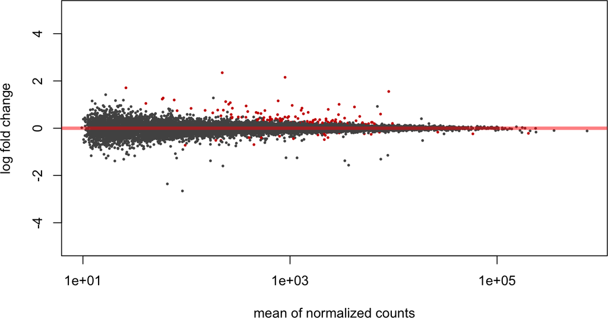

```r
DESeq2::plotMA(dds, ylim=c(-5, 5))
```

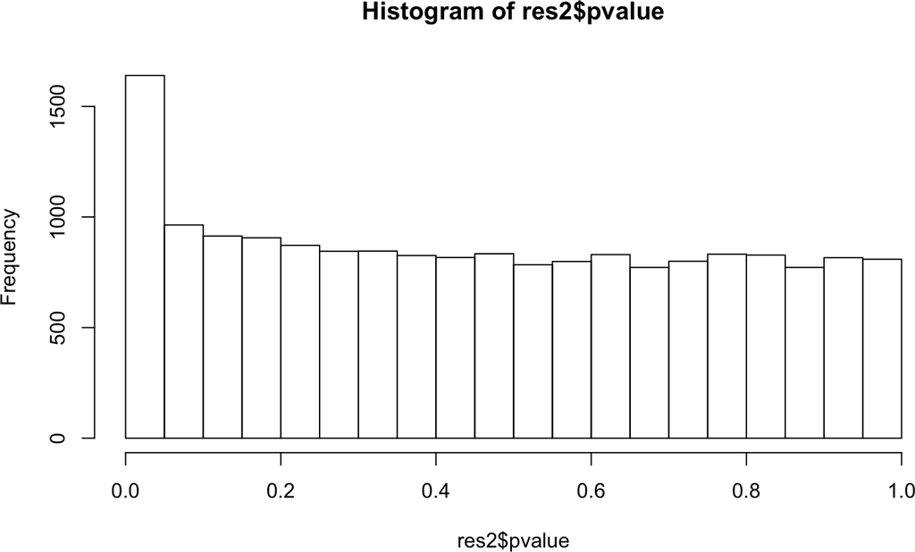

```r
hist(res2$pvalue)
```

This is a good distribution of the p-values. We expect the majority of the genes to be non-differentially expressed, hence leading to a uniform distribution of the p-value and a small portion of genes to be differentially expressed, leading to p-values close to zero.

Another very useful plot is the volcano plot. As far as I know, `DESeq2` does not have an automatic function for that, but it is easy to do it “by hand”.

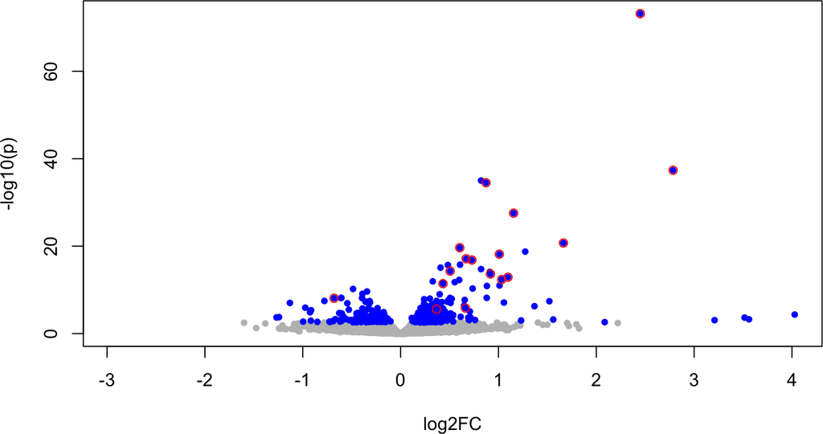

```r
plot(res2$log2FoldChange, -log10(res2$pvalue),
     xlab = "log2FC", ylab = "-log10(p)", pch=20, col="grey")
de <- which(res2$padj <= 0.1)
points(res2[de, "log2FoldChange"],
       -log10(res2[de, "pvalue"]),
       pch=20, col=4)
pos <- which(rownames(res2) %in% c(FCup, FCdown))
points(res2[pos, "log2FoldChange"],
       -log10(res2[pos, "pvalue"]),
       pch=1, col=2)
```

## 7.1 Using all the samples

What happens if we repeat the analysis with all the original samples?

```r
x_orig <- as.factor(rep(c("CC", "FC", "RT"), each=5))
names(x_orig) <- colnames(fc)

filter <- apply(fc, 1, function(x) length(x[which(x>10)])>5)
filtered_orig <- as.matrix(fc)[filter,]

dds_all <- DESeqDataSetFromMatrix(countData = filtered_orig,
                              colData = data.frame(Condition = x_orig,
                                                   Expt = substring(colnames(filtered_orig), 3)),
                              design = ~ Condition)
dds_all <- DESeq(dds_all)

res2_all <- results(dds_all, contrast=c("Condition", "FC", "CC"))
summary(res2_all)
```

```
##
## out of 18008 with nonzero total read count
## adjusted p-value < 0.1
## LFC > 0 (up)       : 72, 0.4%
## LFC < 0 (down)     : 9, 0.05%
## outliers [1]       : 31, 0.17%
## low counts [2]     : 699, 3.9%
## (mean count < 14)
## [1] see 'cooksCutoff' argument of ?results
## [2] see 'independentFiltering' argument of ?results
```

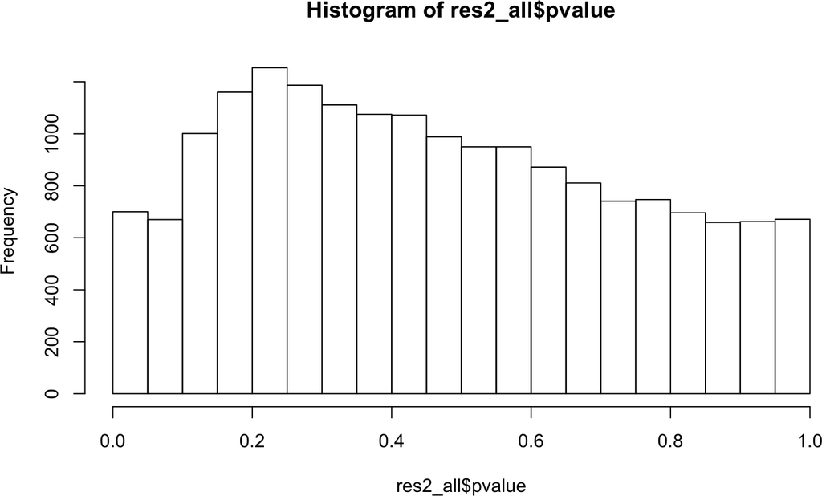

```r
hist(res2_all$pvalue)
```

This is not a good distribution of the p-values. Usually a symptom that the data are affected by batch effects or other unwanted variation.

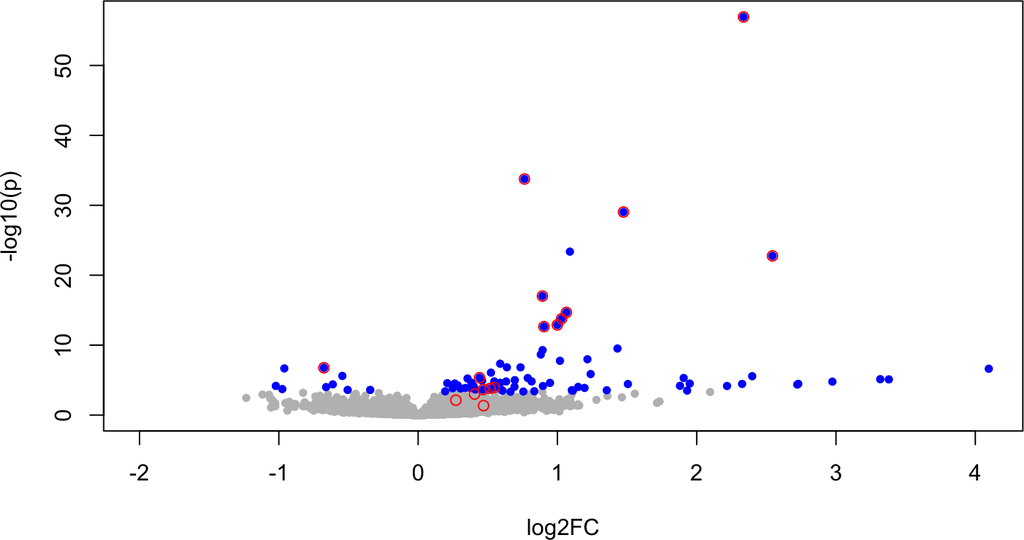

```r
plot(res2_all$log2FoldChange, -log10(res2_all$pvalue),
     xlab = "log2FC", ylab = "-log10(p)", pch=20, col="grey")
de <- which(res2_all$padj <= 0.1)
points(res2_all[de, "log2FoldChange"],
       -log10(res2_all[de, "pvalue"]),
       pch=20, col=4)
pos <- which(rownames(res2_all) %in% c(FCup, FCdown))
points(res2_all[pos, "log2FoldChange"],
       -log10(res2_all[pos, "pvalue"]),
       pch=1, col=2)
```

## 7.2 Accounting for unwanted variation

Sometimes filtering out “bad” samples is not feasible or undesirable. In such cases, we can try and capture the unwanted variation and include it in the model. This is the approach used in the `RUVSeq` package.

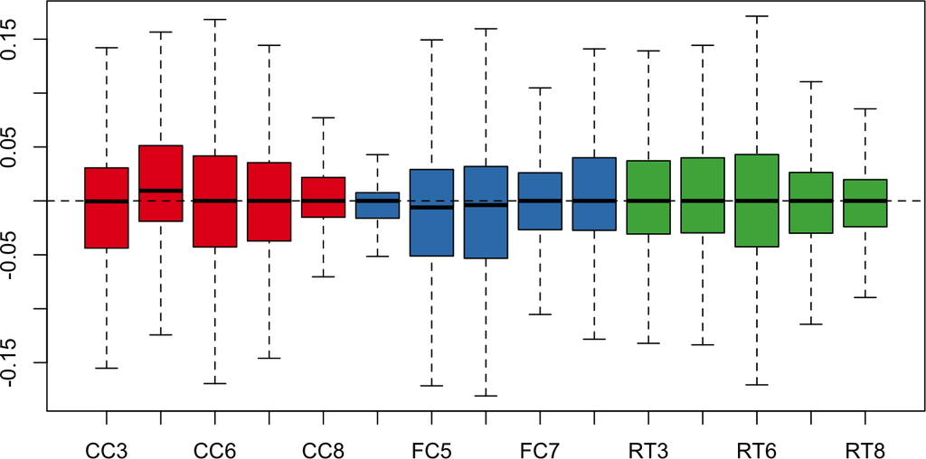

```r
uq <- betweenLaneNormalization(filtered_orig, which="upper")

ruv <- RUVg(uq, cIdx = negCon, k = 5)
plotRLE(ruv$normalizedCounts, col = colors[x_orig], outline=FALSE)
```

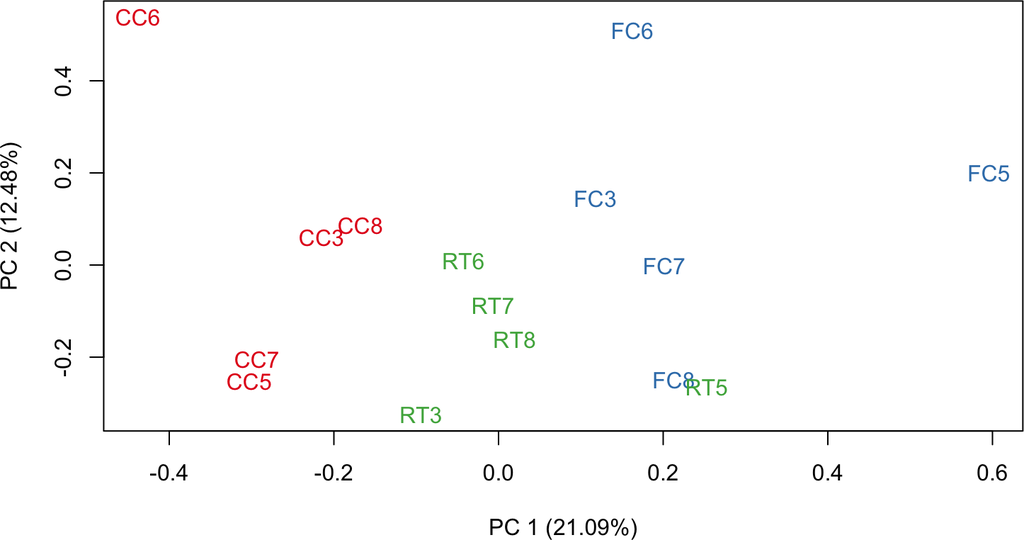

```r
plotPCA(ruv$normalizedCounts, col=colors[x_orig], cex=1, cex.axis=1, cex.lab=1)
```

Now that we checked that these factors account for the unwanted variation, we can include them in the model.

```r
dds_ruv <- DESeqDataSetFromMatrix(countData = filtered_orig,
colData = data.frame(Condition = x_orig, Expt = substring(colnames(filtered_orig), 3), ruv$W),
design = ~ Condition + W_1 + W_2 + W_3 + W_4 + W_5)
dds_ruv <- DESeq(dds_ruv)

res2_ruv <- results(dds_ruv, contrast=c("Condition", "FC", "CC"))
summary(res2_ruv)
```

```
##
## out of 18008 with nonzero total read count
## adjusted p-value < 0.1
## LFC > 0 (up)       : 212, 1.2%
## LFC < 0 (down)     : 135, 0.75%
## outliers [1]       : 0, 0%
## low counts [2]     : 2095, 12%
## (mean count < 30)
## [1] see 'cooksCutoff' argument of ?results
## [2] see 'independentFiltering' argument of ?results
```

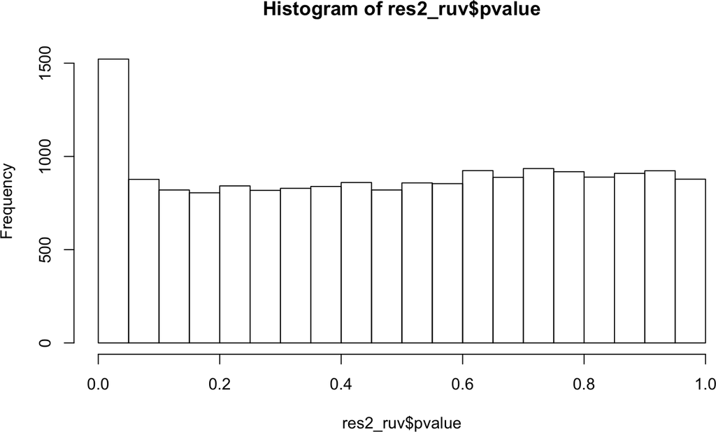

```r
hist(res2_ruv$pvalue)
```

This is a better distribution of the p-values. Demonstrating that we have been able to remove the batch effects/unwanted variations.

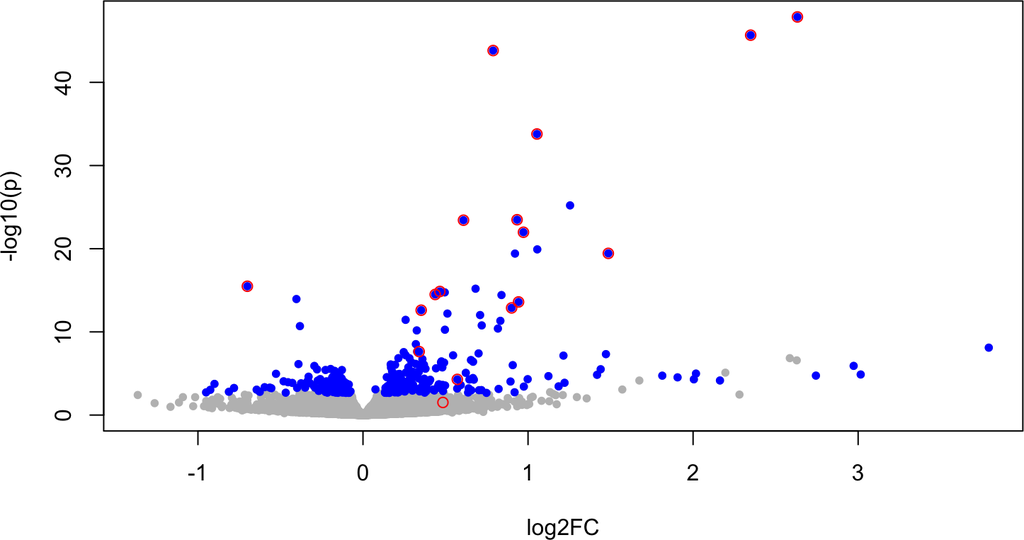

```r
plot(res2_ruv$log2FoldChange, -log10(res2_ruv$pvalue),
     xlab = "log2FC", ylab = "-log10(p)", pch=20, col="grey")
de <- which(res2_ruv$padj <= 0.1)
points(res2_ruv[de, "log2FoldChange"],
       -log10(res2_ruv[de, "pvalue"]),
       pch=20, col=4)
pos <- which(rownames(res2_ruv) %in% c(FCup, FCdown))
points(res2_ruv[pos, "log2FoldChange"],
       -log10(res2_ruv[pos, "pvalue"]),
       pch=1, col=2)
```

# 8 Differential expression with edgeR

Similarly to `DESeq2`, `edgeR` works on a dedicated object, called `DGEList`, that we need to create from our matrix.

```r
y <- DGEList(counts = filtered_orig, group = x_orig)
```

The steps of a typical analysis in `edgeR` are very similar to those of `DESeq2`: calculate the normalization factors, estimate the dispersion parameters, and test for differential expression.

```r
y <- calcNormFactors(y)
design <- model.matrix(~x_orig + ruv$W)
y <- estimateDisp(y, design)
```

To test for differential expression, we first fit a generalized linear model (GLM) and then test using the likelihood ratio test.

```r
fit <- glmFit(y, design)
lrt <- glmLRT(fit, coef=2)
topTags(lrt)
```

```
## Coefficient:  x_origFC
##                        logFC   logCPM       LR       PValue          FDR
## ENSMUSG00000021250 2.3516839 4.124909 379.8879 1.316325e-84 2.370439e-80
## ENSMUSG00000020423 0.7920111 4.646463 251.1991 1.422391e-56 1.280721e-52
## ENSMUSG00000037868 2.6321439 2.023129 212.6784 3.577182e-48 2.147263e-44
## ENSMUSG00000022602 1.4894348 7.483189 166.3244 4.698952e-38 2.115468e-34
## ENSMUSG00000024042 1.0570989 3.890234 156.6427 6.126797e-36 2.012941e-32
## ENSMUSG00000052837 0.9751842 5.942336 156.4629 6.706822e-36 2.012941e-32
## ENSMUSG00000034640 0.6115393 4.079765 152.1562 5.857191e-35 1.426049e-31
## ENSMUSG00000085609 1.2573559 2.341951 152.0003 6.335182e-35 1.426049e-31
## ENSMUSG00000023034 0.9456012 6.428337 119.1746 9.590709e-28 1.918994e-24
## ENSMUSG00000003545 0.9366744 3.446073 114.8365 8.545925e-27 1.538950e-23
```

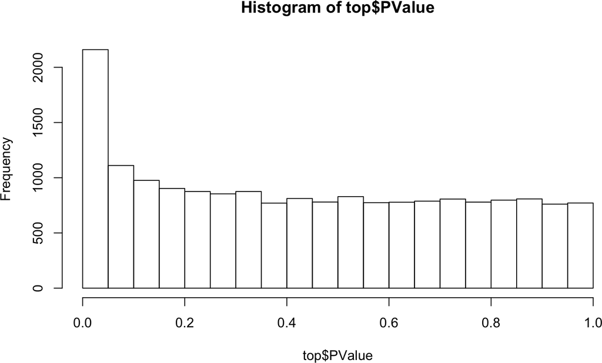

```r
top <- topTags(lrt, n = Inf)$table

hist(top$PValue)
```

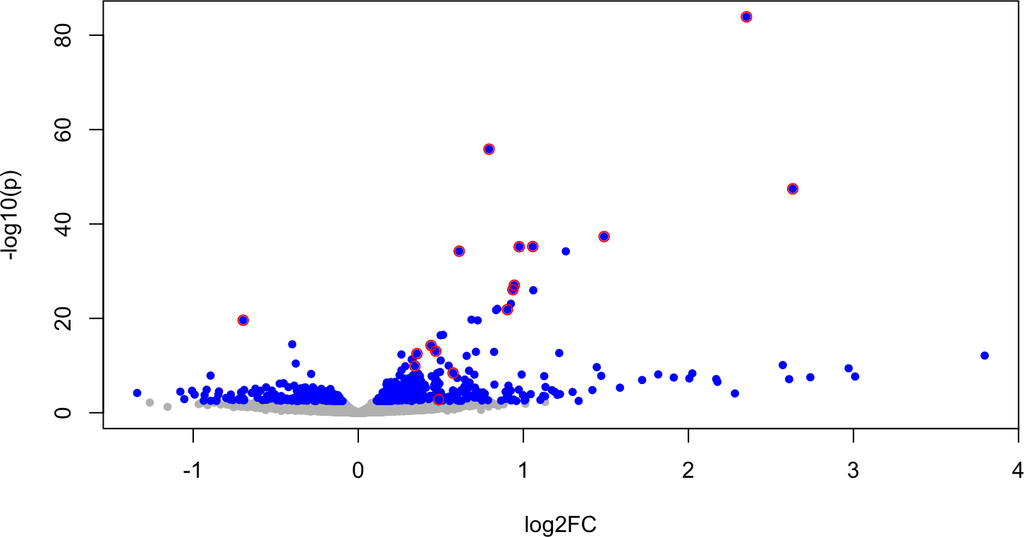

```r
plot(top$logFC, -log10(top$PValue),
     xlab = "log2FC", ylab = "-log10(p)", pch=20, col="grey")

de <- which(top$FDR <= 0.1)
points(top[de, "logFC"],
       -log10(top[de, "PValue"]),
       pch=20, col=4)
pos <- which(rownames(top) %in% c(FCup, FCdown))
points(top[pos, "logFC"],
       -log10(top[pos, "PValue"]),
       pch=1, col=2)
```

We can test contrasts in `edgeR` in the following way. Imagine we want to test the difference between FC and RT.

```r
colnames(design) <- c("Intercept", "FC", "RT",
                      "W1", "W2", "W3", "W4", "W5")
cont <- makeContrasts(FC - RT, levels = colnames(design))
cont
```

```
##            Contrasts
## Levels      FC - RT
##   Intercept       0
##   FC              1
##   RT             -1
##   W1              0
##   W2              0
##   W3              0
##   W4              0
##   W5              0
```

```r
lrt <- glmLRT(fit, contrast = cont)
topTags(lrt)
```

```
## Coefficient:  1*x_origFC -1*x_origRT
##                         logFC    logCPM       LR       PValue         FDR
## ENSMUSG00000046341 -0.2330145 5.8805670 27.36655 1.683178e-07 0.003031066
## ENSMUSG00000031119  0.2091137 5.2421765 20.47505 6.041378e-06 0.054396571
## ENSMUSG00000052551  0.1976208 4.6433435 19.19628 1.179429e-05 0.070797184
## ENSMUSG00000045314 -0.4094197 2.0132070 18.57122 1.636731e-05 0.073685630
## ENSMUSG00000028125  0.8725033 1.7607856 17.75817 2.508376e-05 0.081545964
## ENSMUSG00000021098  0.3352735 2.8885830 17.24482 3.285924e-05 0.081545964
## ENSMUSG00000091158 -0.1903066 4.6874861 16.73208 4.304684e-05 0.081545964
## ENSMUSG00000079681 -0.5111754 0.7899752 16.68812 4.405601e-05 0.081545964
## ENSMUSG00000045648 -0.5166894 3.0189484 16.67575 4.434423e-05 0.081545964
## ENSMUSG00000032575 -0.2554835 5.2802738 16.63600 4.528319e-05 0.081545964
```

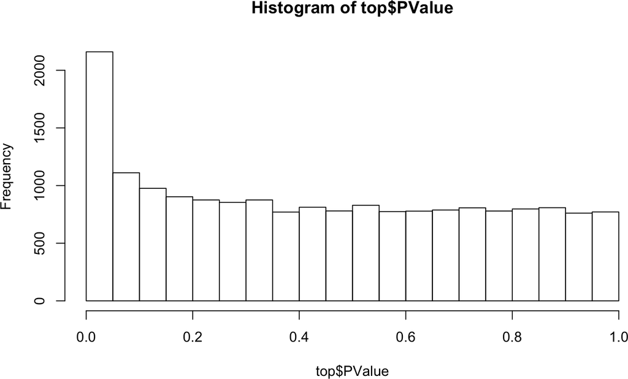

```r
top2 <- topTags(lrt, n = Inf)$table
hist(top$PValue)
```

# 9 A common list of genes

At this point we could want to compare the `edgeR` and the `DESeq2` results in order to obtain a consensul list.

```r
source("R/venn2.R")

sign.edger <- top[de,]
res2_ruv.nna <- res2_ruv[!is.na(res2_ruv$padj ),]
sign.des <- res2_ruv.nna[res2_ruv.nna$padj < 0.05,]
int.genes <- Venn2de(x=rownames(sign.edger), y=rownames(as.data.frame(sign.des)), label1="edgeR", label2="RUV_Deseq")
```

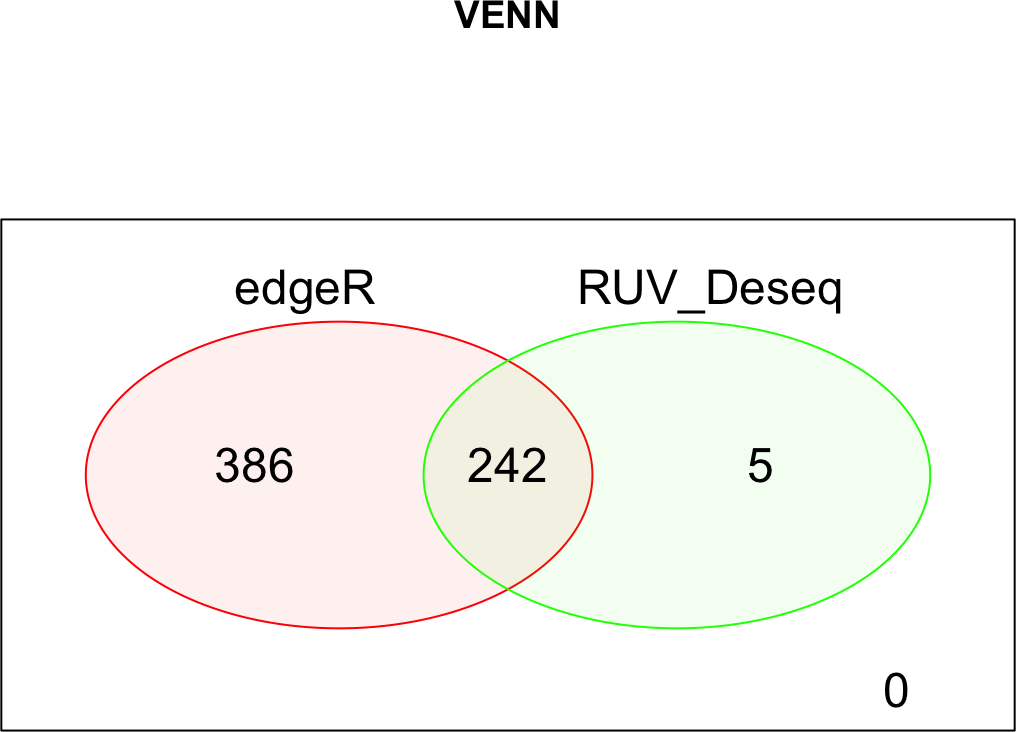

```r
print(head(int.genes))
```

```
## [1] "ENSMUSG00000021250" "ENSMUSG00000020423" "ENSMUSG00000037868"
## [4] "ENSMUSG00000022602" "ENSMUSG00000024042" "ENSMUSG00000052837"
```

# 10 Functional analysis

A list of genes can be used to obtain a first biological insight by looking at some known annotation databases available online. By using the **gprofiler** package we can query some of these databases and looking at the cellular mechanisms mostly affected by the obtained gene list.

```r
library(gProfileR)

go <- gprofiler(query=int.genes, organism="mmusculus", src_filter="GO")

kegg <- gprofiler(query=int.genes, organism="mmusculus", src_filter="KEGG")
print(colnames(go))
```

```
##  [1] "query.number"    "significant"     "p.value"         "term.size"
##  [5] "query.size"      "overlap.size"    "precision"       "recall"
##  [9] "term.id"         "domain"          "subgraph.number" "term.name"
## [13] "relative.depth"  "intersection"
```

```r
print(colnames(kegg))
```

```
##  [1] "query.number"    "significant"     "p.value"         "term.size"
##  [5] "query.size"      "overlap.size"    "precision"       "recall"
##  [9] "term.id"         "domain"          "subgraph.number" "term.name"
## [13] "relative.depth"  "intersection"
```

```r
print(head(go))
```

```
##   query.number significant  p.value term.size query.size overlap.size
## 1            1        TRUE 2.70e-02       247        227           12
## 2            1        TRUE 4.03e-05      1530        227           41
## 3            1        TRUE 5.14e-04      1244        227           34
## 4            1        TRUE 8.54e-05     12641        227          170
## 5            1        TRUE 1.19e-04     12050        227          164
## 6            1        TRUE 2.41e-07      6312        227          111
##   precision recall    term.id domain subgraph.number
## 1     0.053  0.049 GO:0006469     BP               9
## 2     0.181  0.027 GO:0009719     BP               2
## 3     0.150  0.027 GO:0071495     BP               2
## 4     0.749  0.013 GO:0065007     BP               2
## 5     0.722  0.014 GO:0050789     BP               2
## 6     0.489  0.018 GO:0019222     BP               2
##                                        term.name relative.depth
## 1 negative regulation of protein kinase activity              1
## 2                response to endogenous stimulus              1
## 3       cellular response to endogenous stimulus              2
## 4                          biological regulation              1
## 5               regulation of biological process              2
## 6                regulation of metabolic process              3
##                                                                                                                                                                                                                                                                                                          …
## 1                                                                                                                                                                                                                                                                                                        …
## 2                                                                                                                                                                                                                                                                                                        …
## 3                                                                                                                                                                                                                                                                                                        …
## 4 ENSMUSG00000001506,ENSMUSG00000001763,ENSMUSG00000001827,ENSMUSG00000002325,ENSMUSG00000003545,ENSMUSG00000004655,ENSMUSG00000005268,ENSMUSG00000005483,ENSMUSG00000005583,ENSMUSG00000007682,ENSMUSG00000007812,ENSMUSG00000007817,ENSMUSG00000008384,ENSMUSG00000014747,ENSMUSG00000015312,ENSMUSG000…
## 5                                                                                                                   ENSMUSG00000001506,ENSMUSG00000001763,ENSMUSG00000001827,ENSMUSG00000002325,ENSMUSG00000003545,ENSMUSG00000004655,ENSMUSG00000005268,ENSMUSG00000005483,ENSMUSG00000005583,ENSMUSG000…
## 6                                                                                                                                                                                                                                                                                                        …
```

```r
print(head(kegg))
```

```
##   query.number significant  p.value term.size query.size overlap.size
## 1            1        TRUE 8.91e-03        71         88            6
## 2            1        TRUE 4.36e-02       132         88            7
## 3            1        TRUE 5.55e-05       302         88           15
## 4            1        TRUE 3.99e-03        90         88            7
## 5            1        TRUE 8.23e-03        70         88            6
## 6            1        TRUE 7.74e-04       129         88            9
##   precision recall    term.id domain subgraph.number
## 1     0.068  0.085 KEGG:04976    keg               4
## 2     0.080  0.053 KEGG:04926    keg               1
## 3     0.170  0.050 KEGG:04010    keg               3
## 4     0.080  0.078 KEGG:04912    keg               5
## 5     0.068  0.086 KEGG:05031    keg               2
## 6     0.102  0.070 KEGG:04380    keg               6
##                    term.name relative.depth
## 1             Bile secretion              1
## 2  Relaxin signaling pathway              1
## 3     MAPK signaling pathway              1
## 4     GnRH signaling pathway              1
## 5      Amphetamine addiction              1
## 6 Osteoclast differentiation              1
##                                                                                                                                                                                                                                                                                   intersection
## 1                                                                                                                                                                            ENSMUSG00000004655,ENSMUSG00000021670,ENSMUSG00000022376,ENSMUSG00000028645,ENSMUSG00000032193,ENSMUSG00000068323
## 2                                                                                                                                                         ENSMUSG00000001506,ENSMUSG00000021025,ENSMUSG00000021250,ENSMUSG00000022376,ENSMUSG00000034009,ENSMUSG00000052684,ENSMUSG00000053137
## 3 ENSMUSG00000005583,ENSMUSG00000015312,ENSMUSG00000019960,ENSMUSG00000020190,ENSMUSG00000020941,ENSMUSG00000021250,ENSMUSG00000021453,ENSMUSG00000023034,ENSMUSG00000024190,ENSMUSG00000024383,ENSMUSG00000026072,ENSMUSG00000034765,ENSMUSG00000051331,ENSMUSG00000052684,ENSMUSG00000053137
## 4                                                                                                                                                         ENSMUSG00000022376,ENSMUSG00000024383,ENSMUSG00000038418,ENSMUSG00000051331,ENSMUSG00000052684,ENSMUSG00000053137,ENSMUSG00000053819
## 5                                                                                                                                                                            ENSMUSG00000003545,ENSMUSG00000021250,ENSMUSG00000022602,ENSMUSG00000051331,ENSMUSG00000052684,ENSMUSG00000053819
## 6                                                                                                                   ENSMUSG00000002325,ENSMUSG00000003545,ENSMUSG00000020941,ENSMUSG00000021025,ENSMUSG00000021250,ENSMUSG00000026072,ENSMUSG00000052684,ENSMUSG00000052837,ENSMUSG00000053137
```